# Basic Statistics in R

RAdelaide 2025

Author

Affiliation

Dr Stevie Pederson

Black Ochre Data Labs  
The Kids Research Institute Australia

Published

July 9, 2025

# Statistics in R

## Introduction

- `R` has it’s origins as a statistical analysis language (i.e. `S`)
- Purpose of this session is NOT to teach statistical theory
  - I am more of a bioinformatician than statistician
  - I did tutor stats for 3 years
- Perform simple analyses in R
- Up to you to know what you’re doing
  - Or talk to your usual statisticians & collaborators

## Distributions

- `R` comes with nearly every distribution
- Standard syntax for accessing each

## Distributions

| Distribution | Density | Area Under Curve | Quantile | Random |
| --- | --- | --- | --- | --- |
| Normal | `dnorm()` | `pnorm()` | `qnorm()` | `rnorm()` |
| T | `dt()` | `pt()` | `qt()` | `rt()` |
| Uniform | `dunif()` | `punif()` | `qunif()` | `runif()` |
| Exponential | `dexp()` | `pexp()` | `qexp()` | `rexp()` |
| $\chi^2$ | `dchisq()` | `pchisq()` | `qchisq()` | `rchisq()` |
| Binomial | `dbinom()` | `pbinom()` | `qbinom()` | `rbinom()` |
| Poisson | `dpois()` | `ppois()` | `qpois()` | `rpois()` |

## Distributions

- Also Beta, $\Gamma$, Log-Normal, F, Geometric, Cauchy, Hypergeometric etc…

```r
?Distributions
```

## Distributions

**PDF**

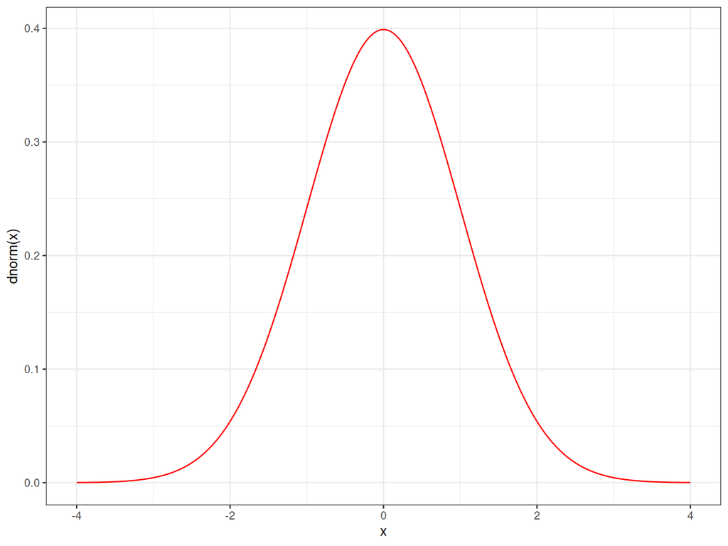

```r
## dnorm gives the classic bell-curve
tibble(
  x = seq(-4, 4, length.out = 1e3)
) |>
  ggplot(aes(x, y = dnorm(x))) +
  geom_line(colour = "red")
```

**CDF**

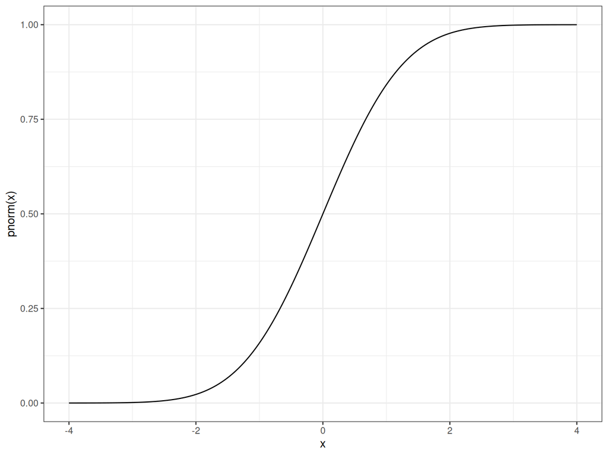

```r
## pnorm gives the area under the
## bell-curve (which sums to 1)
tibble(
  x = seq(-4, 4, length.out = 1e3)
) |>
  ggplot(aes(x, y = pnorm(x))) +
  geom_line()
```

## The T Distribution

- A T distribution looks very much like a Standard normal N(0, 1) but has heavier tails
- This allows for greater uncertainty in the tails

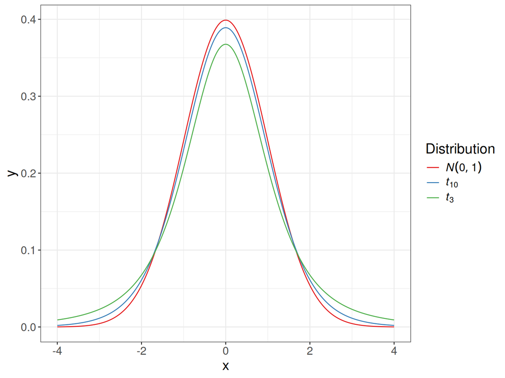

# Tests For Continuous Data

## Data For This Session

- We’ll use the `pigs` dataset from earlier
- Start a new session with new script: `BasicStatistics.R`

```r
library(tidyverse)
library(scales)
library(car)
theme_set(
  theme_bw() + theme(plot.title = element_text(hjust = 0.5))
)
pigs <- file.path("data", "pigs.csv") |>
    read_csv() |>
    mutate(
      dose = fct(dose, levels = c("Low", "Med", "High")),
      supp = fct(supp)
    )
```

## Data For This Session

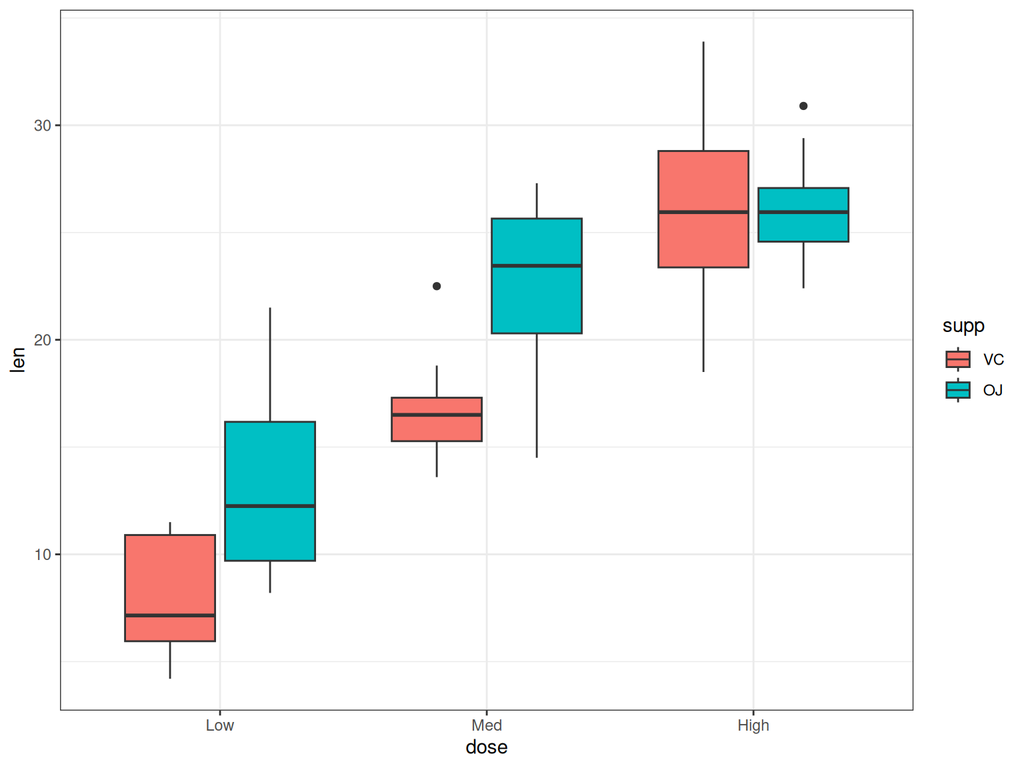

```r
pigs |>
  ggplot(
    aes(x = dose, y = len, fill = supp)
  ) +
    geom_boxplot()
```

## Pop Quiz

**Can anyone define a p-value?**

- A p-value is the probability of observing a test statistic **at least as extreme as the one observed**, assuming the null hypothesis is true.
- In plain English: *If there’s nothing really going on, how likely are we to observe our result, or one even more extreme?*
- A p-value of 0.05 $\implies$ about 1 in 20 times we’ll see something like this in a random sample

## t-tests

- Assumes normally distributed data
- $t$-tests always test $H_0$ Vs $H_A$
  - For data with exactly two groups
- The simplest test is on a simple vector
  - Not particularly meaningful for our data

```r
?t.test
t.test(some_vector)
```

**What is $H_0$ in the above test?**

The true mean of the underlying distribution from which the vector is sampled, is zero: i.e. $\mu = 0$

## t-tests

When comparing the means of two vectors

$$H_0: \mu_{1} = \mu_{2} \\
H_A: \mu_{1} \neq \mu_{2}$$

We could use two vectors (i.e. `x` & `y`)

```r
vc <- dplyr::filter(pigs, supp == "VC")$len
oj <- dplyr::filter(pigs, supp == "OJ")$len
t.test(x = vc, y = oj)
```

**Is This a Paired Test?**

No

## t-tests

- An alternative is the `R` formula method: `len~supp`
  - Length is a response variable
  - Supplement is the predictor
- Can *only use one predictor for a T-test* $\implies$ otherwise it’s linear regression

```r
t.test(len~supp, data = pigs)
```

**Did this give the same results?**

## t-tests

- Do we think the variance is equal between the two groups?

```r
pigs |> summarise(sd = sd(len), .by = supp)
```

```
# A tibble: 2 × 2
  supp     sd
  <fct> <dbl>
1 VC     8.27
2 OJ     6.61
```

- We can use Levene’s Test to formalise this
  - From the package `car`
  - Bartlett’s test is very similar (`bartlett.test()`)

```r
leveneTest(len~supp, data = pigs)
```

## t-tests

- Now we can assume equal variances
  - By default, variances are assumed to be unequal

```r
t.test(len~supp, data = pigs, var.equal = TRUE)
```

- If relevant, the confidence interval can also be adjusted

## Wilcoxon Tests

- We assumed the above dataset was normally distributed:  
  **What if it’s not?**
- Non-parametric equivalent is the *Wilcoxon Rank-Sum* Test (aka *Mann-Whitney*)
- This assigns ranks to each value based on their value
  - The test is then performed on ranks **NOT** the values
  - Tied values can be problematic
- Test that the centre of each underlying distribution is the same

```r
wilcox.test(len~supp, data = pigs)
```

## A Brief Comment

- Both of these are suitable *for comparing two groups*
- T-tests assume Normally Distributed Data underlies the random sample
  - Are robust to some deviation from normality
  - Data can sometimes be transformed (e.g. `sqrt()`, `log()` etc)
- The Wilcoxon Rank Sum Test assumes nothing about the underlying distribution
  - Much less powerful with small sample sizes
  - Highly comparable at n $\geq$ 30
- The package `coin` implements a range of non-parametric tests

# Tests For Categorical Data

## $\chi^2$ Test

- Here we need counts and categories
- Commonly used in *Observed Vs Expected*

$$H_0: \text{No association between groups and outcome}$$
$$H_A: \text{Association between groups and outcome}$$

**When we shouldn’t use a $\chi^2$ test?**

## $\chi^2$ Test

```r
pass <- matrix(
  c(25, 8, 6, 15), nrow = 2,
  dimnames = list(
    c("Attended", "Skipped"),
    c("Pass", "Fail"))
)
pass
```

```
         Pass Fail
Attended   25    6
Skipped     8   15
```

```r
pass_chisq <- chisq.test(pass)
pass_chisq
```

```
    Pearson's Chi-squared test with Yates' continuity correction

data:  pass
X-squared = 9.8359, df = 1, p-value = 0.001711
```

## Fisher’s Exact Test

- $\chi^2$ tests became popular in the days of the printed tables
  - We now have computers
- Fisher’s Exact Test is preferable in the cases of low cell counts
  - (Or any other time you feel like it…)
- Same $H_0$ as the $\chi^2$ test
- Uses the hypergeometric distribution

```r
fisher.test(pass)
```

## Summary of Tests

- `t.test()`, `wilcox.test()`
- `chisq.test()`, `fisher.test()`
- `shapiro.test()`, `bartlett.test()`
- `car::leveneTest()`
  - Tests for normality or homogeneity of variance
- `binomial.test()`, `poisson.test()`
- `kruskal.test()`, `ks.test()`

## `htest` Objects

- All produce objects of class `htest`
- Is really a `list`
  - Use `names()` to see what other values are returned

```r
names(pass_chisq)
```

```
[1] "statistic" "parameter" "p.value"   "method"    "data.name" "observed"
[7] "expected"  "residuals" "stdres"
```

- Will vary slightly between tests
- Can usually extract p-values using `test$p.value`

```r
pass_chisq$p.value
```

```
[1] 0.001711398
```

## `htest` Objects

```r
## Have a look at the list elements produced by fisher.test
fisher.test(pass) |> names()
```

```
[1] "p.value"     "conf.int"    "estimate"    "null.value"  "alternative"
[6] "method"      "data.name"
```

```r
## Are these similar to those produced by t.test?
t.test(len~supp, data = pigs) |> names()
```

```
 [1] "statistic"   "parameter"   "p.value"     "conf.int"    "estimate"
 [6] "null.value"  "stderr"      "alternative" "method"      "data.name"
```

- There is a function `print.htest()` which organises the printout for us
- We’ll come back to methods later, but this is a common way for output to be produced
- The will be a print function for objects of each class, i.e. `print.class_of_object`

## References

Cochran, William G. 1954. “Some Methods for Strengthening the Common χ 2 Tests.” *Biometrics* 10 (4): 417.